# 06_Sequence_Diagrams

## Sequence діаграми.

**Діаграма послідовності (Sequence diagram)** показує взаємодії між об’єктами з погляду повідомлень, якими обмінюються у часі. Визначає, як і як функції об’єкта перебувають у системі.

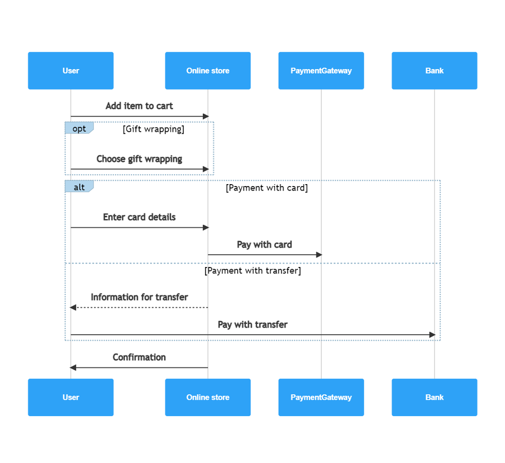

Діаграма послідовності структурована таким чином, що є тимчасовою шкалою, яка починається зверху і поступово спускається, відзначаючи послідовність взаємодій. У кожного об’єкта є стовпець, а повідомлення, якими обмінюються, представлені стрілками.

**Лінія життя.** Діаграма послідовності складається з кількох ліній життя, які мають бути розташовані горизонтально у верхній частині діаграми.

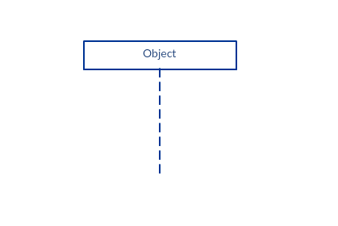

Жодні два позначення лінії життя не повинні перекривати один одного. Вони репрезентують різні об’єкти або частини, які взаємодіють один з одним у системі під час послідовності.

Нотація лінії життя з символом актора використовується, якщо конкретна діаграма послідовності належить варіанту використання.

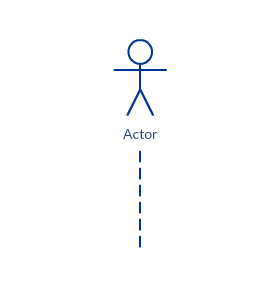

Лінія життя з елементом-суб’єктом є системними даними. Наприклад, у додатку “Обслуговування клієнтів” організація-замовник керуватиме всіма даними, які стосуються клієнта.

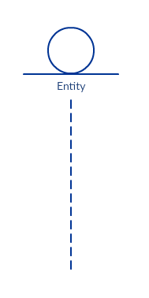

Лінія життя з граничним елементом позначає системний кордон/програмний елемент у системі; наприклад, екрани інтерфейсу користувача, шлюзи бази даних або меню, з якими взаємодіють користувачі, є межами.

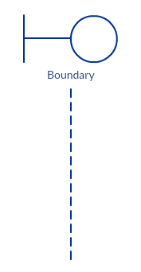

Лінія життя з елементом контролю свідчить про контролюючу організацію чи менеджера. Він організовує і складає графік взаємодії між кордонами та суб’єктами і виступає як посередник між ними.

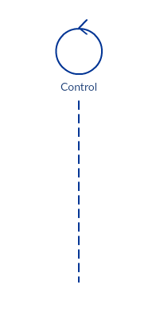

**Бари активації** розташовані на лінії життя. Використовуються для вказівки, що об’єкт активний під час взаємодії між двома об’єктами. Довжина вказує на тривалість перебування об’єктів у активному стані.

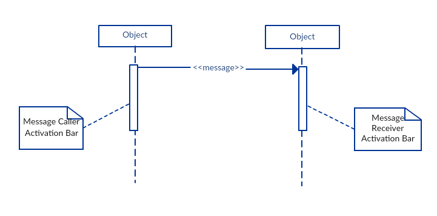

**На діаграмі послідовності взаємодія між двома об’єктами відбувається, коли** один об’єкт надсилає повідомлення іншому. Використання бару активації на лініях життя повідомлення (об’єкт, що надсилає повідомлення) та одержувача повідомлення (об’єкт, який отримує повідомлення) вказує на те, що обидва активні/створюються під час обміну повідомленням.

**Стрілки повідомлень** вказують на повідомлення у діаграмі послідовності. Повідомлення може йти у будь-якому напрямку. Стрілка повідомлення має опис (підпис повідомлення).

**Синхронне повідомлення** використовується, коли відправник чекає, поки приймач обробить повідомлення і повернеться, перш ніж продовжити з іншим повідомленням.

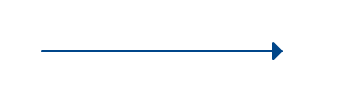

**Асинхронне повідомлення** використовується, коли сторона, що викликає, не чекає, поки приймач обробить повідомлення і повернеться, перш ніж відправити інші повідомлення іншим об’єктам в системі.

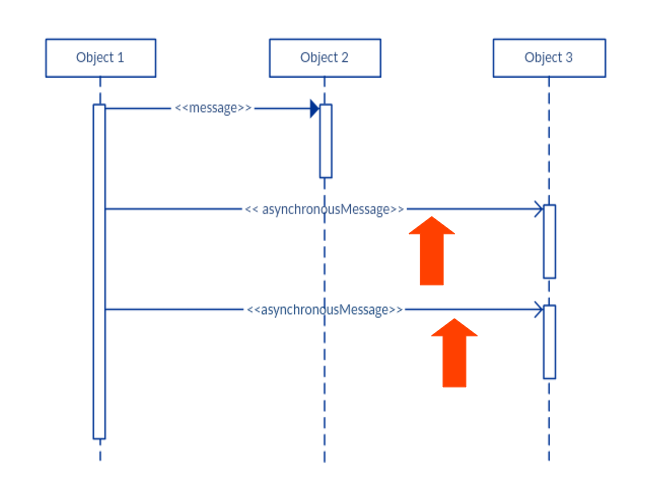

**Повідомлення, що повертається** використовується для вказівки на те, що приймач повідомлення закінчив обробку повідомлення і повертає управління відправнику.

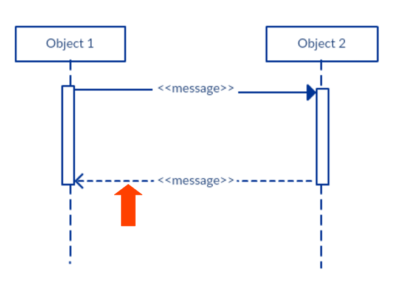

**Повідомлення про створення об’єкта** створює новий об’єкт. Об’єкти можуть бути створені відповідно до повідомлення, що надсилається.

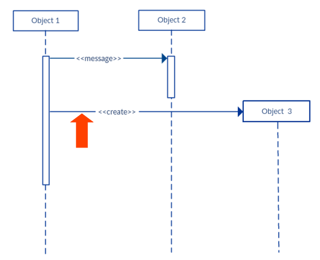

**Повідомлення про знищення об’єкта** видаляє об’єкт. Об’єкти, які більше не потрібні, можуть бути видалені.

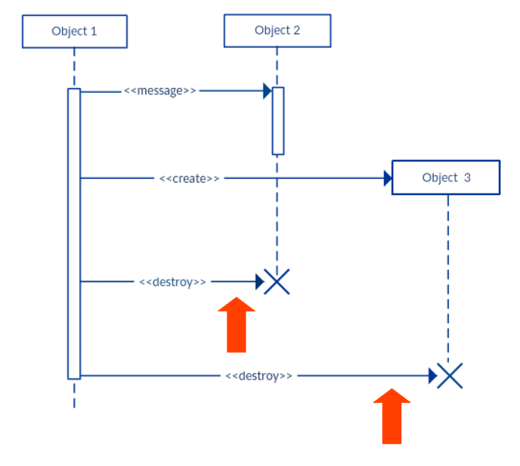

**Рефлексивне повідомлення.** Коли об’єкт надсилає повідомлення самому собі.

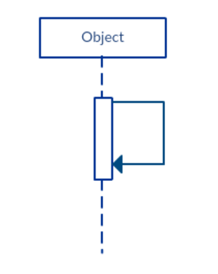

**Коментар.** Для приміток та описів.

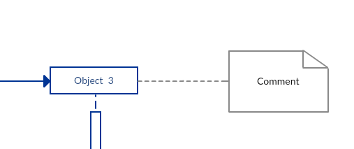

**Фрагмент діаграми послідовності** – прямокутна рамка (контейнер) поверх частини діаграми. Використовується для більш структурованого відображення складних взаємодій, альтернативних потоків і циклів. Контейнер фрагмента – операнд взаємодії. Мітка у рамці, у верхньому лівому кутку, - оператор взаємодії.

Найбільш поширені фрагменти:

- Опція (option).
- Альтернатива (alternative).
- Цикл (Loop).

**Опція (option).** Фрагмент опції є простим вибором поведінки між двома варіантами. Оператор взаємодії – `opt`. Змодельований фрагмент послідовності або станеться, або станеться, залежно від конкретної умови.

Замовник або вибере подарункове пакування, або ні.

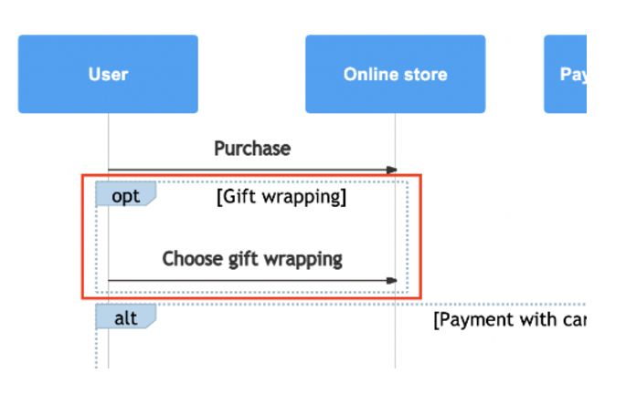

**Альтернатива (alternative).** Альтернативний фрагмент моделює класичний оператор програмування `if-then-else`. Оператор взаємодії – `alt`. У цьому фрагменті потік повідомлень зображує взаємовиключний вибір між двома шляхами. Процес йде або цим, або іншим шляхом.

Не всі товари можна придбати за допомогою банківського переказу.

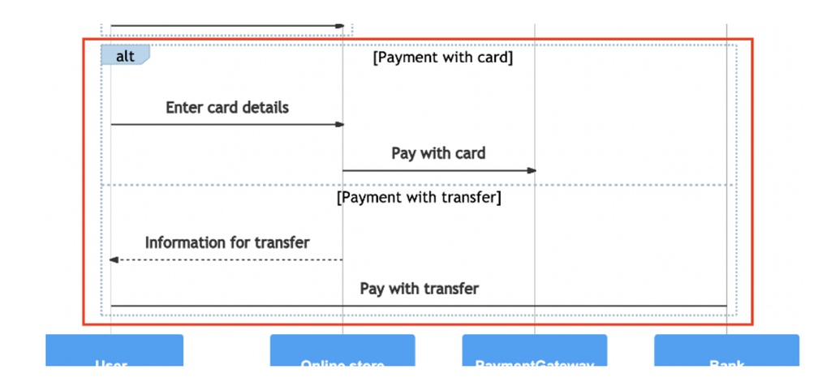

**Цикл (Loop).** Фрагменти циклу дозволяють моделювати послідовність, що повторюється. Оператор взаємодії – `loop`. Наприклад, ввести в касовий апарат кілька товарів для кожного покупця, перш ніж подати покупцеві загальну суму та запросити оплату.

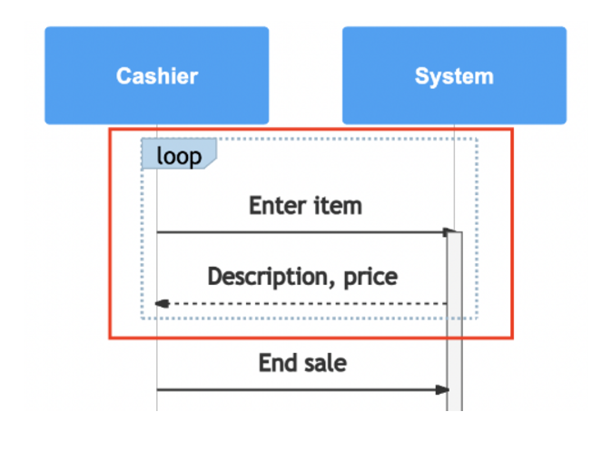

**Особливості створення Sequence діаграми.**

Діаграма послідовності представляє сценарій або потік подій в одному варіанті використання. Потік повідомлень діаграми послідовностей ґрунтується на описі конкретного варіанту використання.

Попередньо треба підготувати повний опис те, що робить конкретний варіант використання.

Визначити об’єкти, які братимуть участь у діаграмі послідовності.

Визначити взаємодії, які відбуватимуться між об’єктами.

На кожному етапі взаємодії вказати, якими повідомленнями мають обмінюватись об’єкти між собою.

Потрібно визначити достатню кількість деталей. Занадто багато деталей захаращує діаграму та ускладнює читання.